# RNAseq Workflow

Julian Politsch

6/7/2021

### Step 1-Setup:

First we should make a fresh conda environment with only the nessasary packages in order to avoid future errors:

```
    $conda create -n deseq
    $conda install fastqc multiqc trimgalore salmon sra-tools=2.11
```

#### Step 2-Download Data From SRA:

This study contains 12 RNA-seq samples from yeast and there are 3 replicates for 4 conditions.

First download a list of Run IDs in a file named SRR_lst.txt, and then download the SRA files with:

```
$cd Desktop/deseq/data
$cat SRR_Acc_list.txt | xargs -n 1 prefetch ; fastq-dump -0 home/julian/Desktop/deseq/data/fastq_dump *.sra --gzip
```

This step takes a lot of time and storage, each file is almost one GB its better to run it in the background by pressing “Ctrl + Z” followed by “$bg", then the progress is shown by entering "$jobs”

#### Step 3-Check reads quality:

In the same directory, containing the fastq.gz files we run the following command in order to check the quality of our reads:

```
$ cd ~/Desktop/deseq/data/fastq_dump
$ fastqc -o ~/Desktop/deseq/data/fastqc_reports *.fastq.gz
```

Comparing out samples to the fastqc [good illumina data](https://www.bioinformatics.babraham.ac.uk/projects/fastqc/good_sequence_short_fastqc.html#M8) and [bad illumina data](https://www.bioinformatics.babraham.ac.uk/projects/fastqc/bad_sequence_fastqc.html) we can see a few flags in our data:

##### Duplicate Sequences:

In a diverse library most sequences will occur only once in the final set. A low level of duplication may indicate a very high level of coverage of the target sequence, but a high level of duplication is more likely to indicate some kind of enrichment bias (eg PCR over amplification).

Since we used rnaSEQ of osmostressed cells this warning message can be ignored for now as we would expect some sequences to be over represented considering the data type, and likely does not show a bias towards an enrichment type.

In order to be able to observe lowly expressed transcripts it is therefore common to greatly over-sequence high expressed transcripts, and this will potentially create large set of duplicates. This will result in high overall duplication in this test, and will often produce peaks in the higher duplication bins.

##### Per base sequence content:

In a random library you would expect that there would be little to no difference between the different bases of a sequence run, so the lines in this plot should run parallel with each other. The relative amount of each base should reflect the overall amount of these bases in your genome, but in any case they should not be hugely imbalanced from each other.

It’s worth noting that some types of library will always produce biased sequence composition, normally at the start of the read. Libraries produced by priming using random hexamers (including nearly all RNA-Seq libraries) and those which were fragmented using transposes inherit an intrinsic bias in the positions at which reads start. This bias does not concern an absolute sequence, but instead provides enrichment of a number of different K-mers at the 5’ end of the reads. Whilst this is a true technical bias, it isn’t something which can be corrected by trimming and in most cases doesn’t seem to adversely affect the downstream analysis. It will however produce a warning or error in this module.

#### Step 4-Compare all fastQC reports:

MultiQC is a tool to aggregate results from bioinformatics analysis logs across multiple samples into a single report, perfect for summarizing the output of numerous bioinformatics tools.

Simply run with:

```
$ multiqc -i multiqc_report_untrimmed -o ~/Desktop/deseq/data .
```

While in the directory you want the tool to search

#### Step 5-Quality and adaptor trimming with Trim Galore

Although the official documentation says the per base sequence content warning can be safely ignored, we should still try to trim the data in order to improve the quality of the model.

```
$conda install -c bioconda trim-galore
$for fastq in *.fastq.gz
$do
>trim_galore --quality 25 --stringency 5 --length 35 --fastqc $fastq
$done
```

After running the multiqc report on the trimmed samples, we see the same error flags as the untrimmed data, although around 3 million (0.5%) of the base pairs were able to be trimmed. We do see a marked decrease in low base quality, and removing primers is always a good idea.

We will move on with the trimmed files

#### Step 6-Quantifying of samples with salmon

First we need to donwload the reference transcriptome of S. Cerevisiae [Here](http://ftp.ensembl.org/pub/release-104/fasta/saccharomyces_cerevisiae/cdna/Saccharomyces_cerevisiae.R64-1-1.cdna.all.fa.gz)

Next we create an index for salmon using:

```
salmon index -t Saccharomyces_cerevisiae.R64-1-1.cdna.all.fa.gz -i S_cere_index
```

And then we can write a quick recursive nano script to run all the samples through salmon in one command

```
for file in *.fq.gz
do
salmon quant -i S_cere_index -l A -r ${file} --validateMappings -o ${file}_quant
done
```

and in the same directory we run

```
$sh [sh file name].sh
```

and the result will be 12 nicely formatted quantified expression files which we can take to deseq analysis in R

# Rstudio Portion

## Step 7-Differential Expression Analysis in R:

First install all the packages:

```
if (!requireNamespace("BiocManager", quietly = TRUE))
  install.packages("BiocManager")
BiocManager::install()

packages <- c("tximport", "GenomicFeatures", "DESeq2", "clusterProfiler", "AnnotationDbi", "org.Sc.sgd.db", "org.Mm.eg.db")
BiocManager::install(packages)

install.packages(c("readr", "ggplot2"))
```

Next

### Setup

```r
library(DESeq2)
library(knitr)
library(tximport)
library(GenomicFeatures)
library(readr)
library(ggplot2)
library(stringi)
library("AnnotationDbi")
library("org.Sc.sgd.db")
library(DOSE)
library(tximport)
library(clusterProfiler)
```

### Initial Statistics for each quant file

```r
counts <- read.table("/Users/julian/Desktop/deseq/quants/quant.sf", header = TRUE, row.names = 1)
summary(counts)
```

```
##      Length      EffectiveLength          TPM              NumReads
##  Min.   :   51   Min.   :    2.583   Min.   :    0.00   Min.   :     0
##  1st Qu.:  531   1st Qu.:  281.000   1st Qu.:    2.56   1st Qu.:    99
##  Median : 1065   Median :  815.000   Median :    8.34   Median :   363
##  Mean   : 1329   Mean   : 1084.224   Mean   :  152.18   Mean   :  2011
##  3rd Qu.: 1761   3rd Qu.: 1511.000   3rd Qu.:   27.35   3rd Qu.:  1018
##  Max.   :14733   Max.   :14483.000   Max.   :68558.03   Max.   :490555
```

### Load sample Metadata

```r
colData <-  read.csv("/Users/julian/Desktop/deseq/sampledata.csv", header = FALSE)
colnames(colData) <- c("fastq", "sample")
files <- file.path("/Users/julian/Desktop/deseq/results", colData$directory, "quant.sf")
```

### Data import and quantification from Salmon

Salmon is a tool for transcript quantification salmon has two phases, indexing to a reference transcriptome, and quantification

```r
#Labeling
colData$group <- rep(c("wt_nostress", "wt_stress", "mut_nostress", "mut_stress"), each = 3)
colData$directory <- dir("/Users/julian/Desktop/deseq/results/")
rownames(colData) <- colData$sample

#quant.sf file paths containing the quantification results
files <- file.path("/Users/julian/Desktop/deseq/results", colData$directory, "quant.sf")
names(files) <- colData$sample
txi.inf.rep <- tximport::tximport(files, type = "salmon", txOut = TRUE)
```

### Create txtb object

Object which maps the 5’ and 3’ UTR and maps the coding sequences, exons, to their associated genome, in this case S. Cerevisiae

```r
txdb <- GenomicFeatures::makeTxDbFromGFF("/Users/julian/Desktop/deseq/Saccharomyces_cerevisiae.R64-1-1.104.gtf")
k <- keys(txdb, keytype = "GENEID")
tx2gene <- AnnotationDbi::select(txdb, keys = k, keytype = "GENEID", columns = "TXNAME")

#Reorder columns of tx2gene
tx2gene <- tx2gene[, c("TXNAME", "GENEID")]

#Check tx2gene
head(tx2gene)

#Import salmon quantification data
txi.salmon <- tximport(files = files, type = "salmon", tx2gene = tx2gene, ignoreTxVersion = TRUE)

# check imported data ----
head(txi.salmon$counts)
```

### Checking quantification correctness

```r
# check if sample names match between objects
identical(x = rownames(colData), y = colnames(txi.salmon$counts))
```

```
## [1] TRUE
```

### Filtering non-expressed genes

```r
dds <- DESeqDataSetFromTximport(txi = txi.salmon, colData = colData, design = ~group)
dds <- DESeq(dds)

keep <- rowSums(counts(dds)) > 1
table(keep)
```

```
## keep
## FALSE  TRUE
##   110  6461
```

```r
dds <- dds[keep, ]
dds$group <- relevel(x = dds$group, ref = "wt_nostress")
```

### DeSEQ pipeline

```r
dds <- DESeq(dds)
res <- results(dds)

ws_wns <- results(dds, contrast = c("group", "wt_stress" ,"wt_nostress"))
ms_mns <- results(dds, contrast = c("group", "mut_stress", "mut_nostress"))
ms_ws <- results(dds, contrast = c("group", "mut_stress", "wt_stress"))
mns_wns <- results(dds, contrast = c("group", "mut_nostress", "wt_nostress"))
```

### Finding DE genes

```r
#remove genes with NA values
de1 <- ws_wns[!is.na(ws_wns$padj),]
#select genes with adjusted p-values below 0.1
de1 <- de1[de1$padj < 0.1,]
#select genes with absolute log2 fold change above 1 (two-fold change)
de1 <- de1[abs(de1$log2FoldChange) > 1,]

de2 <- ms_mns[!is.na(ms_mns$padj),]
de2 <- de2[de2$padj < 0.1,]
de2 <- de2[abs(de2$log2FoldChange) > 1,]

de3 <- ms_ws[!is.na(ms_ws$padj),]
de3 <- de3[de3$padj < 0.1,]
de3 <- de3[abs(de3$log2FoldChange) > 1,]

de4 <- mns_wns[!is.na(mns_wns$padj),]
de4 <- de4[de4$padj < 0.1,]
de4 <- de4[abs(de4$log2FoldChange) > 1,]

# Now these objects are only those genes with padj < 0.1 and log2fold change >1 as: de1, de2, de3, de4
```

### MA Plots

A **MA plot** is useful to observe if the data normalization worked well. The **MA plot** is a scatter plot where the x-axis denotes the average of normalized counts across samples and the y-axis denotes the log fold change in the given contrast. Most points are expected to be on the horizontal 0 line (most genes are not expected to be differentially expressed).

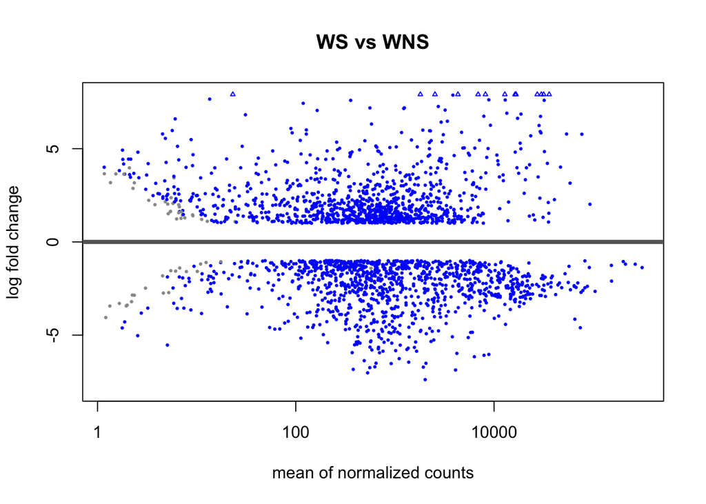

```r
ws_wns <- ws_wns[order(ws_wns$pvalue), ]
DESeq2::plotMA(de1, title('WS vs WNS'), alpha = 0.05)
```

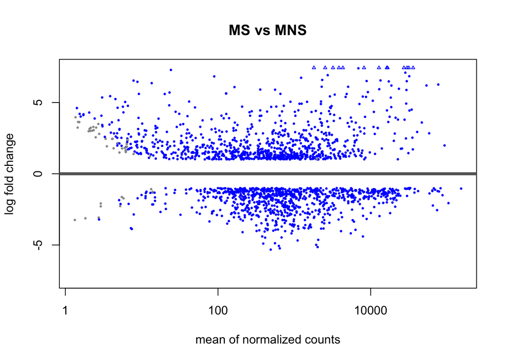

```r
ms_mns <- ms_mns[order(ms_mns$pvalue), ]
DESeq2::plotMA(de2, title('MS vs MNS'),alpha = 0.05)
```

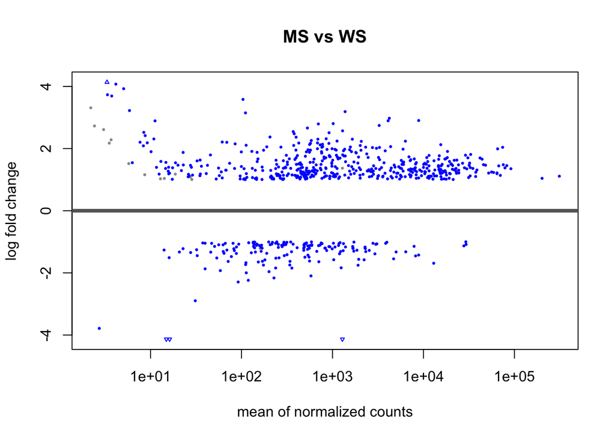

```r
ms_ws <- ms_ws[order(ms_ws$pvalue), ]
DESeq2::plotMA(de3,title('MS vs WS'), alpha = 0.05)
```

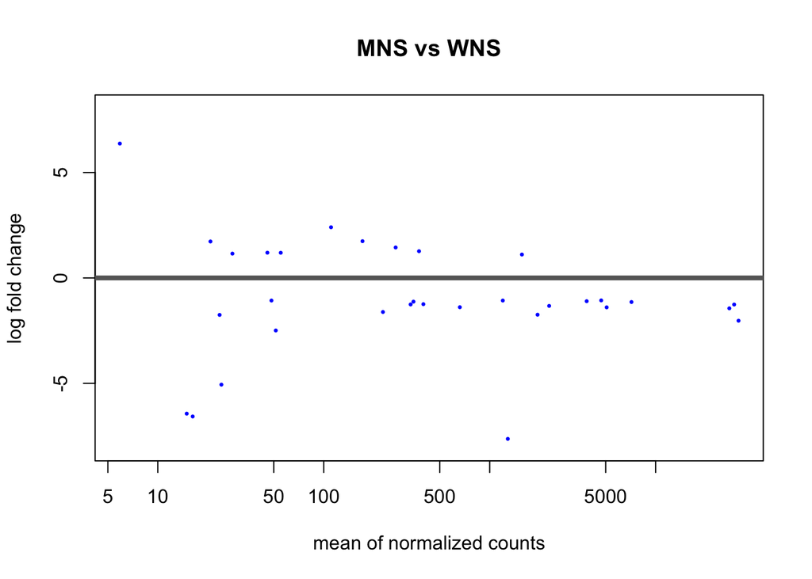

```r
mns_wns <- mns_wns[order(mns_wns$pvalue), ]
DESeq2::plotMA(de4, title('MNS vs WNS'), alpha = 0.05)
```

### Sample Distances and PCA plots

A final diagnosis is to check the biological reproducibility of the sample replicates in a PCA plot or a heatmap.

To plot the PCA results, we need to extract the **normalized counts** from the DESeqDataSet object.

It is possible to color the points in the scatter plot by the variable of interest, which helps to see if the replicates cluster well.

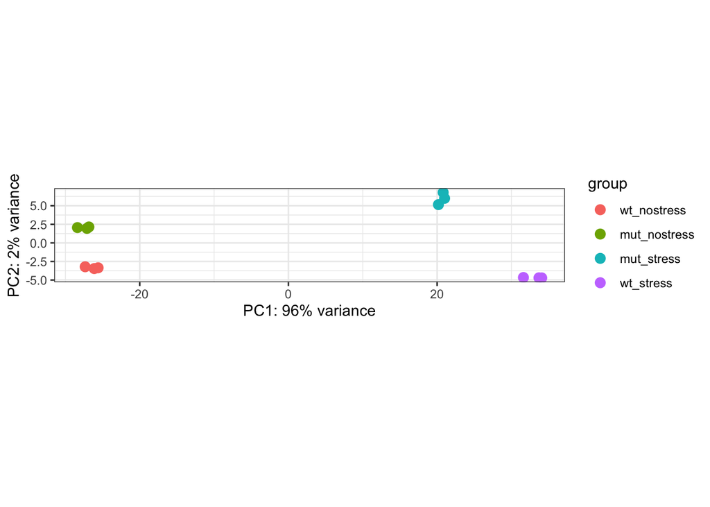

```r
# Pkgs
library("pheatmap")
library("RColorBrewer")

# PCA Plots
rld <- rlog(dds)
DESeq2::plotPCA(rld, ntop = 500, intgroup = 'group') +
  theme_bw()
```

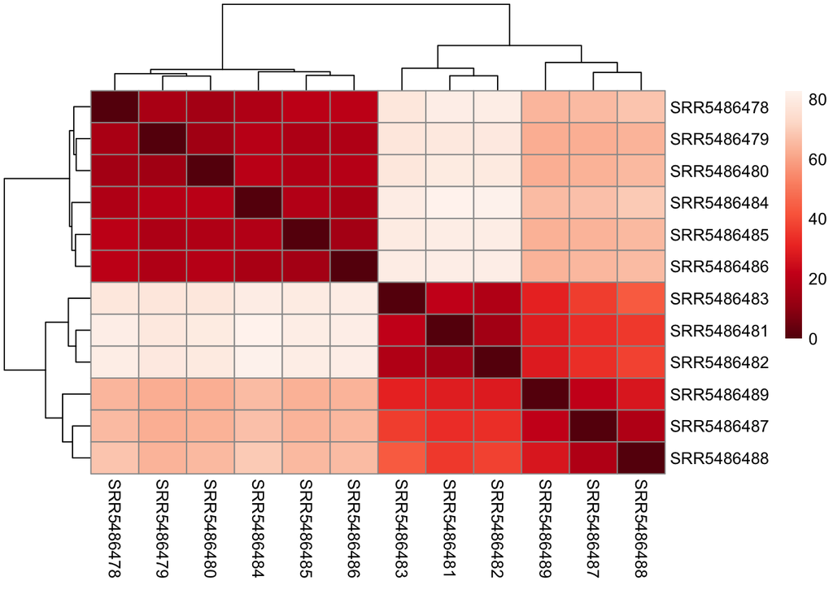

```r
# Sample Dist.
sampleDists <- dist(t(assay(rld)))

sampleDistMatrix <- as.matrix( sampleDists )
colors <- colorRampPalette( rev(brewer.pal(9, "Reds")) )(255)

pheatmap(sampleDistMatrix,
         clustering_distance_rows = sampleDists,
         clustering_distance_cols = sampleDists,
         col = colors)
```

### Go enrichment analysis (Gene Ontology)

Gene ontology aims to cluster groups of genes that are up or down regulated based on cellular role or specific pathway. Here we only want to look at those upregulated

##### WS vs WNS

```r
de1go <- de1[de1$padj < 0.05,]
de1go <- de1go[(de1go$log2FoldChange) > 1,]

de1go$symbol <- mapIds(org.Sc.sgd.db,
                     keys=rownames(de1go),
                     column="GENENAME",
                     keytype="ENSEMBL",
                     multiVals="first")

go1 <- clusterProfiler::enrichGO(row.names(de1go), "org.Sc.sgd.db", keyType = "ENSEMBL", ont = "BP")
clusterProfiler::buildGOmap(go1)
```

##### MS vs MNS

```r
de2go <- de2[de2$padj < 0.05,]
de2go <- de2go[(de2go$log2FoldChange) > 1,]
de2go$symbol <- mapIds(org.Sc.sgd.db,
                     keys=rownames(de2go),
                     column="GENENAME",
                     keytype="ENSEMBL",
                     multiVals="first")


go2 <- clusterProfiler::enrichGO(row.names(de2go), "org.Sc.sgd.db", keyType = "ENSEMBL", ont = "BP")
clusterProfiler::buildGOmap(go2)
```

##### MS vs WS

```r
de3go <- de3[de3$padj < 0.05,]
de3go <- de3go[(de3go$log2FoldChange) > 1,]
de3go$symbol <- mapIds(org.Sc.sgd.db,
                     keys=rownames(de3go),
                     column="GENENAME",
                     keytype="ENSEMBL",
                     multiVals="first")


go3 <- clusterProfiler::enrichGO(row.names(de3go), "org.Sc.sgd.db", keyType = "ENSEMBL", ont = "BP")
clusterProfiler::buildGOmap(go3)
```

##### MNS vs WNS

```r
de4go <- de4[de4$padj < 0.05,]
de4go <- de4go[(de4go$log2FoldChange) > 1,]
de4go$symbol <- mapIds(org.Sc.sgd.db,
                     keys=rownames(de4go),
                     column="GENENAME",
                     keytype="ENSEMBL",
                     multiVals="first")


go4 <- clusterProfiler::enrichGO(row.names(de4go), "org.Sc.sgd.db", keyType = "ENSEMBL", ont = "BP")
clusterProfiler::buildGOmap(go4)
```

#### Results

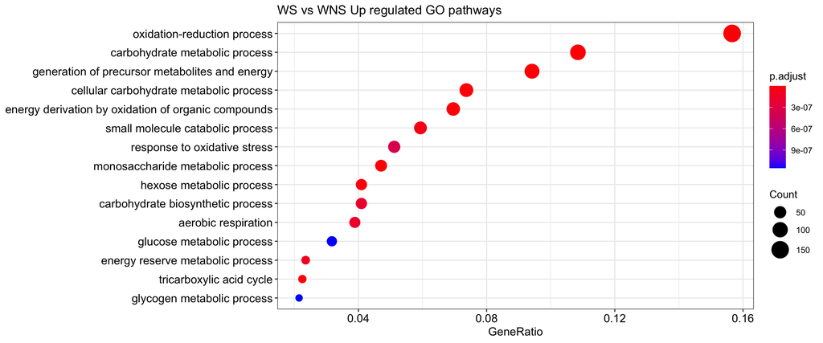

```r
library(ggplot2)
library(DOSE)
dotplot(go1, showCategory=15, title = "WS vs WNS Up regulated GO pathways")
```

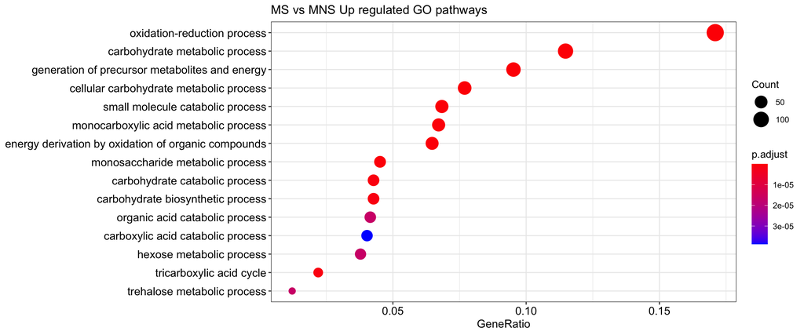

```r
dotplot(go2, showCategory=15, title = "MS vs MNS Up regulated GO pathways")
```

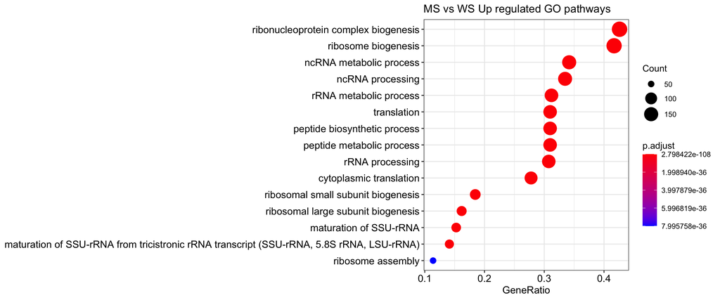

```r
dotplot(go3, showCategory=15, title = "MS vs WS Up regulated GO pathways")
```

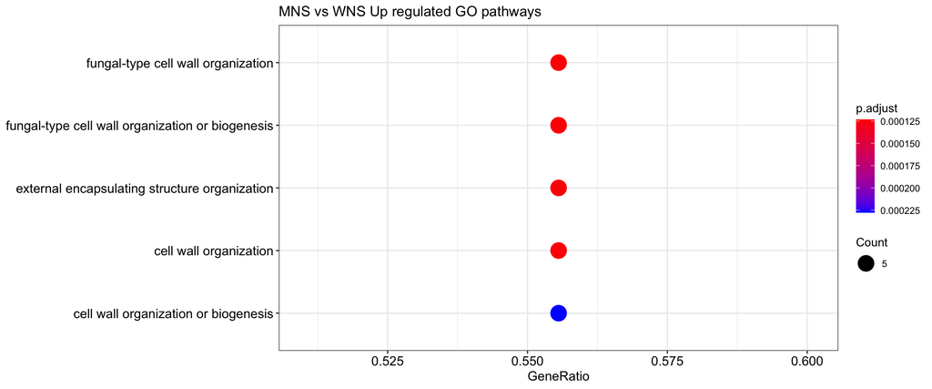

```r
dotplot(go4, showCategory=15, title = "MNS vs WNS Up regulated GO pathways")
```

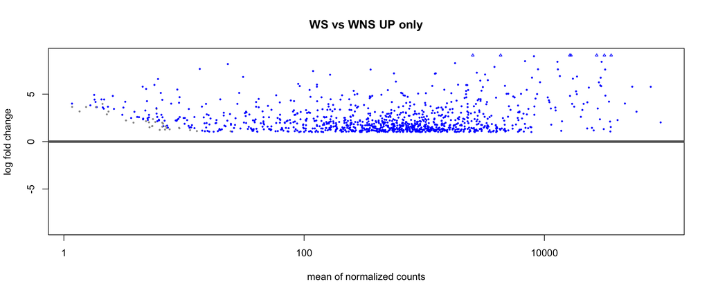

```r
#since we are looking for only upregulated genes the new MAplots will look like:
de1ex <- de1[(de1$log2FoldChange) > 1,]
DESeq2::plotMA(de1ex, title('WS vs WNS UP only'), alpha = 0.05)
```

## Step 7

```r
counts <- read_tsv("RawCounts.tsv")
colnames(counts)[1] <- "GENE_ID"
colnames(counts)[2:13] <- rownames(colData)
countData <- as.matrix(subset(counts, select = c(-GENE_ID)))
summary(countData)
```

```
##    SRR5486478         SRR5486479       SRR5486480       SRR5486481
##  Min.   :     0.0   Min.   :     0   Min.   :     0   Min.   :     0.0
##  1st Qu.:    52.0   1st Qu.:    72   1st Qu.:    63   1st Qu.:    60.2
##  Median :   341.0   Median :   466   Median :   397   Median :   387.0
##  Mean   :  1956.7   Mean   :  3075   Mean   :  2486   Mean   :  2063.0
##  3rd Qu.:   986.8   3rd Qu.:  1415   3rd Qu.:  1178   3rd Qu.:  1299.2
##  Max.   :442556.0   Max.   :742744   Max.   :586476   Max.   :481832.0
##    SRR5486482       SRR5486483         SRR5486484       SRR5486485
##  Min.   :     0   Min.   :     0.0   Min.   :     0   Min.   :     0.0
##  1st Qu.:    59   1st Qu.:    68.0   1st Qu.:    55   1st Qu.:    47.0
##  Median :   371   Median :   427.5   Median :   393   Median :   300.0
##  Mean   :  1867   Mean   :  1851.8   Mean   :  2342   Mean   :  2001.0
##  3rd Qu.:  1233   3rd Qu.:  1297.2   3rd Qu.:  1164   3rd Qu.:   924.8
##  Max.   :420637   Max.   :399627.0   Max.   :542786   Max.   :442781.0
##    SRR5486486       SRR5486487       SRR5486488      SRR5486489
##  Min.   :     0   Min.   :     0   Min.   :     0   Min.   :     0
##  1st Qu.:    40   1st Qu.:    80   1st Qu.:    61   1st Qu.:    86
##  Median :   271   Median :   419   Median :   322   Median :   458
##  Mean   :  1811   Mean   :  2508   Mean   :  2369   Mean   :  2310
##  3rd Qu.:   845   3rd Qu.:  1339   3rd Qu.:  1095   3rd Qu.:  1428
##  Max.   :431055   Max.   :738062   Max.   :845854   Max.   :592818
```

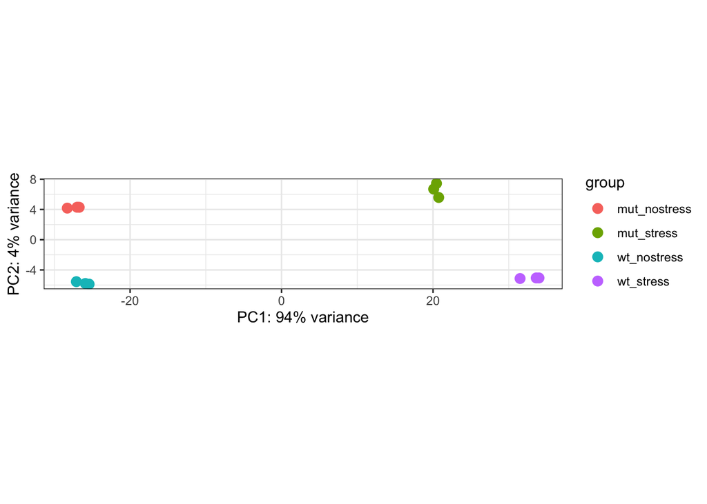

```r
# DESeq2 pipeline
dds <- DESeqDataSetFromMatrix(countData = countData, colData = colData, design = ~group)
# filtering not expressed genes
keep <- rowSums(counts(dds)) > 1
dds <- DESeq(dds)
# PCA
rld <- rlog(dds)
DESeq2::plotPCA(rld, ntop = 500, intgroup = 'group') +
  theme_bw()
```

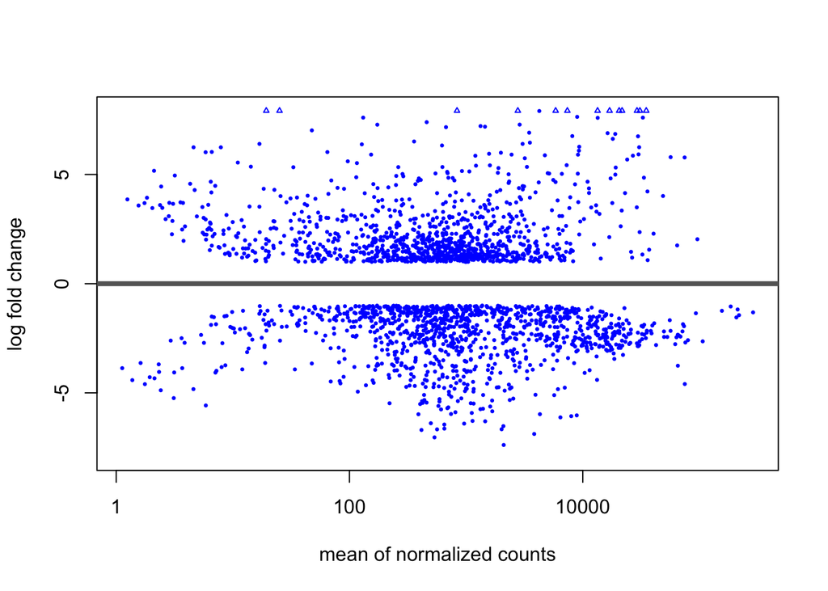

```r
# save the results of DE analysis
WSvsWN2 <- results(dds, contrast = c("group", "wt_stress" ,"wt_nostress"))
MSvsMN2 <- results(dds, contrast = c("group", "mut_stress", "mut_nostress"))
MSvsWS2 <- results(dds, contrast = c("group", "mut_stress", "wt_stress"))
MNvsWN2 <- results(dds, contrast = c("group", "mut_nostress", "wt_nostress"))

WSvsWN2 <- WSvsWN2[!is.na(WSvsWN2$padj),]
WSvsWN2 <- WSvsWN2[WSvsWN2$padj < 0.05,]
WSvsWN2 <- WSvsWN2[abs(WSvsWN2$log2FoldChange) > 1,]
DESeq2::plotMA(WSvsWN2, alpha = 0.05)
```

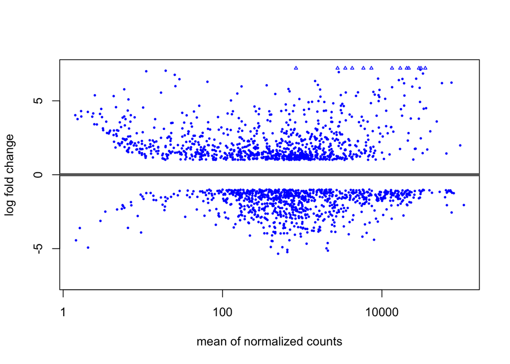

```r
MSvsMN2 <- MSvsMN2[!is.na(MSvsMN2$padj),]
MSvsMN2 <- MSvsMN2[MSvsMN2$padj < 0.05,]
MSvsMN2 <- MSvsMN2[abs(MSvsMN2$log2FoldChange) > 1,]
DESeq2::plotMA(MSvsMN2, alpha = 0.05)
```

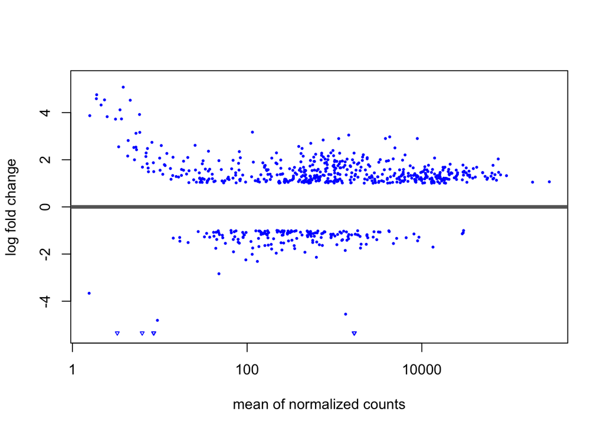

```r
MSvsWS2 <- MSvsWS2[!is.na(MSvsWS2$padj),]
MSvsWS2 <- MSvsWS2[MSvsWS2$padj < 0.05,]
MSvsWS2 <- MSvsWS2[abs(MSvsWS2$log2FoldChange) > 1,]
DESeq2::plotMA(MSvsWS2, alpha = 0.05)
```

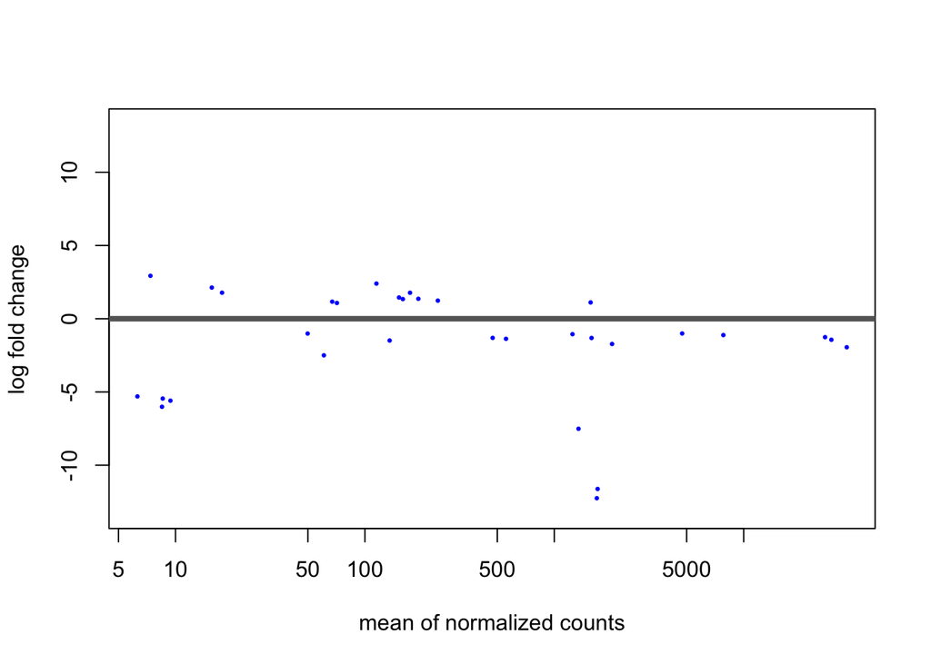

```r
MNvsWN2 <- MNvsWN2[!is.na(MNvsWN2$padj),]
MNvsWN2 <- MNvsWN2[MNvsWN2$padj < 0.05,]
MNvsWN2 <- MNvsWN2[abs(MNvsWN2$log2FoldChange) > 1,]
DESeq2::plotMA(MNvsWN2, alpha = 0.05)
```

### Q1 and Q2

How many genes are differentially expressed at the thresholds of padj < 0.05? And padj < 0.1?

```r
de1q1 <- ws_wns[!is.na(ws_wns$padj),]
de1q1 <- de1q1[de1q1$padj < 0.1,]
de1q1 <- de1q1[abs(de1q1$log2FoldChange) > 1,]
#thresholds of padj < 0.1
nrow(de1q1)
```

```
## [1] 2253
```

```r
#thresholds of padj < 0.05
de1q1 <- de1q1[de1q1$padj < 0.05,]
nrow(de1q1)
```

```
## [1] 2202
```

```r
de2q1 <- ms_mns[!is.na(ms_mns$padj),]
de2q1 <- de2q1[de2q1$padj < 0.1,]
de2q1 <- de2q1[abs(de2q1$log2FoldChange) > 1,]

#thresholds of padj < 0.1
nrow(de2q1)
```

```
## [1] 1878
```

```r
#thresholds of padj < 0.05
de2q1 <- de2q1[de2q1$padj < 0.05,]
nrow(de2q1)
```

```
## [1] 1833
```

```r
de3q1 <- ms_ws[!is.na(ms_ws$padj),]
de3q1 <- de3q1[de3q1$padj < 0.1,]
de3q1 <- de3q1[abs(de3q1$log2FoldChange) > 1,]

#thresholds of padj < 0.1
nrow(de3q1)
```

```
## [1] 654
```

```r
#thresholds of padj < 0.05
de3q1 <- de3q1[de3q1$padj < 0.05,]
nrow(de3q1)
```

```
## [1] 640
```

```r
de4q1 <- mns_wns[!is.na(mns_wns$padj),]
de4q1 <- de4q1[de4$padj < 0.1,]
de4q1 <- de4q1[abs(de4q1$log2FoldChange) > 1,]

#thresholds of padj < 0.1
nrow(de4q1)
```

```
## [1] 348
```

```r
#thresholds of padj < 0.05
de4q1 <- de4q1[de4q1$padj < 0.05,]
nrow(de4q1)
```

```
## [1] 32
```

### Q3

How many genes at the thresholds of padj < 0.05 are upregulated ( > 1)?

```r
de1q1 <- de1q1[(de1q1$log2FoldChange) > 1,]
de2q1 <- de2q1[(de2q1$log2FoldChange) > 1,]
de3q1 <- de3q1[(de3q1$log2FoldChange) > 1,]
de4q1 <- de4q1[(de4q1$log2FoldChange) > 1,]
nrow(de1q1)
```

```
## [1] 1068
```

```r
nrow(de2q1)
```

```
## [1] 926
```

```r
nrow(de3q1)
```

```
## [1] 476
```

```r
nrow(de4q1)
```

```
## [1] 10
```

### Q4

Choice one of the GO enrichment results and report how many categories are significant (p.adjust < 0.05). Hint: first convert the object with GO results with as.data.frame function.

```r
go1DataFrame <- as.data.frame(go1)
nrow(go1DataFrame)
```

```
## [1] 177
```

How many genes are present in the most enriched category of the GO enrichment result?

```r
max(go1DataFrame$Count)
```

```
## [1] 153
```

Which corresponds to oxidation reduction processes (logical)

### Q5

Are the numbers of significant differentially expressed genes of Step 7 the same as the results in Step 5?

```r
nrow(WSvsWN2)
```

```
## [1] 2267
```

```r
nrow(de1)
```

```
## [1] 2253
```

The number of significant dif. expressed genes in step 7 and step 5 is very similar, we can account for trimming as the margin of error, and the results from step 5 are likely more accurate.